# Simulation Wright-Fisher model with R

Maria Izabel

## Exercise goals

In the following exercise you will:

1. **Learn** the assumptions of Wright-Fisher and Coalescence Model.
2. **Simulate** different scenarios using the different models.
3. **Understand** the concept and effects of genetic drift and effective population size in the different scenarios.

## Introduction to population genetics

A lot of population genetics theory is focused on describing the changes of allele frequencies through time. Once we understand how and why the frequencies of alleles change, we have learned a great portion of evolution.

There are two most important factors that cause allele frequencies to change through time: **natural selection** and **genetic drift**. **Genetic drift** is the **random change of allele frequencies** in populations of finite sizes. Genetic drift occurs because more or less copies of an allele by chance can be transmitted to the next generation. This can occur because by chance the individuals carrying a particular allele can leave more or less offspring in the next generation. In a sexual diploid population genetic drift also occurs because Mendelian transmission means that only one of the two alleles in an individual, chosen at random at a locus, is transmitted to the offspring.

Genetic drift can play a role in the dynamics of all alleles and populations, but it will play the biggest role for neutral alleles. A neutral polymorphism occurs when the segregating alleles at a polymorphic site have no discernible differences in their effect on fitness. And because has no effect on fitness, natural selection is not truly orchestrating those changes.

For now (Chapter 2 and 3) we will only focus our attention on the effect of genetic drift on shaping allele frequencies. But later in this course you will see that we can include selection into the models.

Population geneticists have developed a number of different models to describe genetic drift. The most common model is the **Wright-Fisher** model. And is built based in multiple assumptions that will be discussed below.

During the 1980s mathematicians and biologists used part of the concepts of **Wright-Fisher** model and developed the **Coalescence theory**, which could be readly used and applied for real data.

The differences between two models are quite simple: while Wright-Fisher models changes of allele frequencies forward in time, the coalescence theory considers a sample and the genealogical history of the sample, in other words: backwards in time.

Just to test you knowledge I first ask you too questions:

1. What are the assumptions of Wright-Fisher model? What is the distributions used for modelling allele frequencies?
2. In a sample of two gene copies taken from a population, what is the distribution and expectation of the time until the two copies find a most recent common ancestor?

## Exercises using the Wright-Fisher model

(based on scripts by Graham Coop and Fernando Racimo)

Download the R script simulateWF.R from this github repository into a folder in your computer, then cd into that folder and start running the R console:

```r
setwd("/Users/PM/Dropbox/PHD/POPGEN_SUMMERCOURSE/")
source("simulateWF.R") # sourcing the functions of the code
```

This script contains a set of functions for simulating the Wright-Fisher model, both forwards and backwards in time. We’ll play with these functions to gain some intuition about how the models work.

## 1 - Thinking forwards in time: 2 alleles

### Wright-Fisher model

First, we’ll run a Wright-Fisher model beginning with a population with two alleles. The population will have size 2N = 10 (so N = 5 diploid individuals) and we’ll run the simulation for 15 generations:

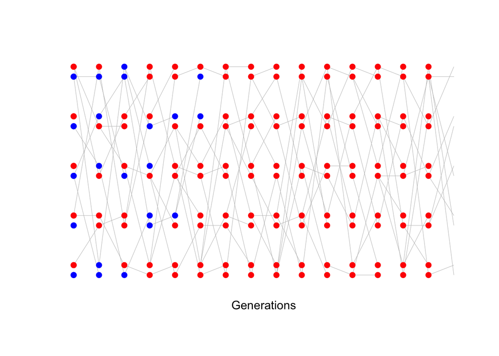

```
##  [1] 5 5 4 4 2 2 0 0 0 0 0 0 0 0 0
```

```r
WF_twoalleles(5,15)
```

3. What do you observe plotted on the screen?
1. Run this line 10 times, and record how many times the red allele fixes, how many times the blue allele fixes and how many times the population remains polymorphic (both the blue and the red allele still co-exist). Compare your results with your neighbor. Does there seem to be a preference for whether the blue or red allele fixes? Why do you think this is so? Hint: check the frequency of the two alleles at the beginning of the simulation.

You may have noticed that a vector of values also gets printed into the console every time we run this simulation. This is the allele counts of the blue allele. We can use this vector to trace the frequency of the blue allele over time:

```r
bluecounts <- WF_twoalleles(5,15)
```

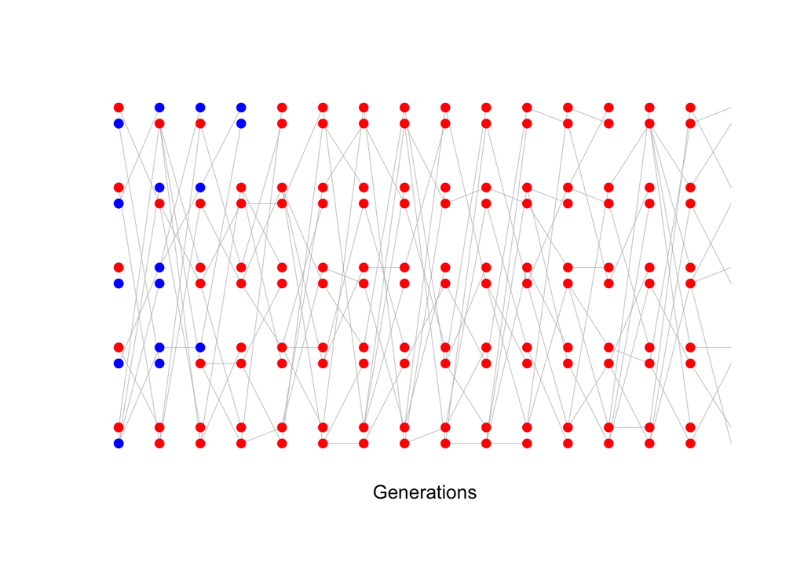

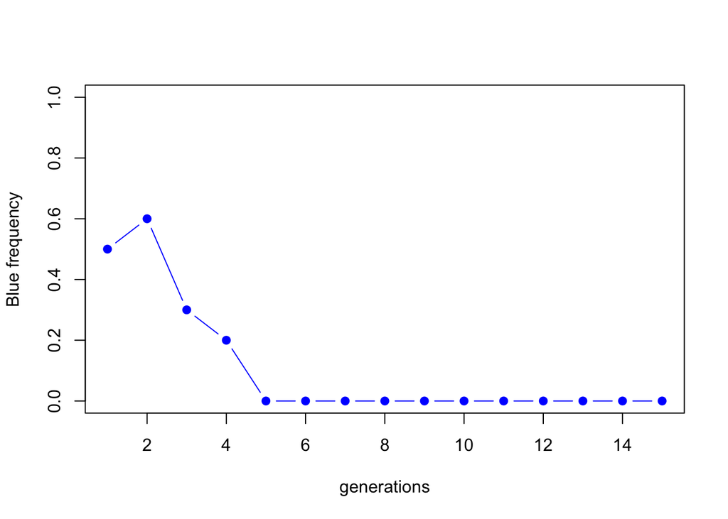

```r
bluefreq <- bluecounts / (2 * 5)
plot(bluefreq,ylim=c(0,1),type="b",col="blue",pch=19,xlab="generations",ylab="Blue frequency")
```

2. Repeat exercise a) but with N=3 and N=10. Do alleles tend to “fix” faster when N is large or when N is small?

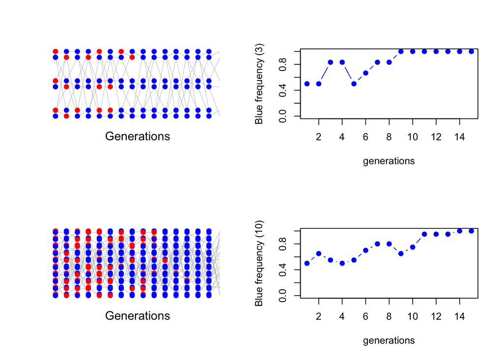

## 2 - Thinking forwards in time: many alleles

We can also run a Wright-Fisher model with more than two alleles. The function below begins with a population in which each individual contains two distinct alleles, which are different from all other alleles in the population.

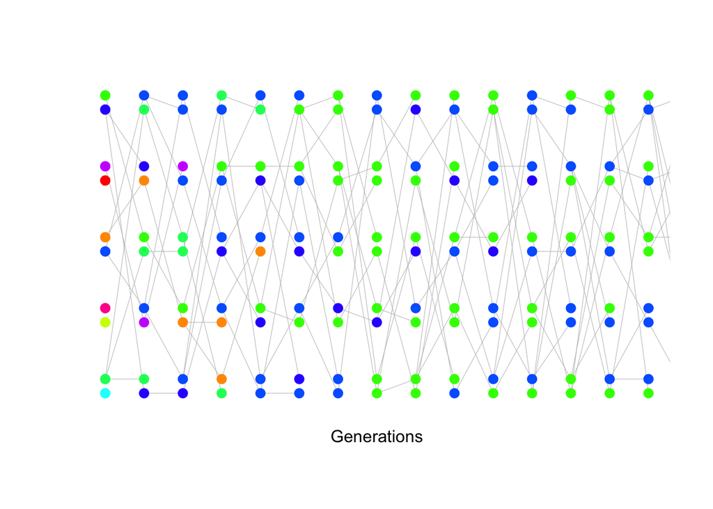

```r
WF_manyalleles(5,15)
```

1. What happens to the allelic diversity (number of alleles present) as time goes forward? Are there more or less heterozygotes at the end of the simulation than at the beginning?
2. Check what happens to allelic diversity over time, when N = 3 and when N = 10.

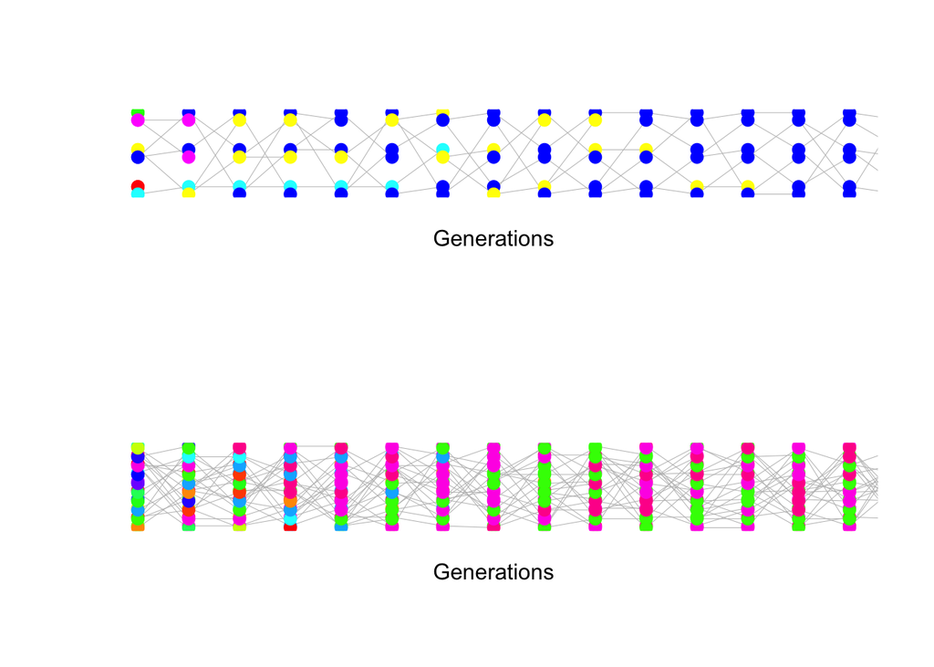

## 3 - Thinking backwards in time

So far, we’ve been running the Wright-Fisher model forwards in time. We began with a population of individuals with (possibly) distinct alleles and observed what happened as we approached the present. Now, we’ll start in the present and go backwards in time. Specifically, we’ll aim to trace the lineages of particular individuals that exist in the present and see how they “coalesce” (find a common ancestor) in the past.

1. We will trace the genealogy of 3 lineages in a population of size N = 10 (2N = 20) over 20 generations:

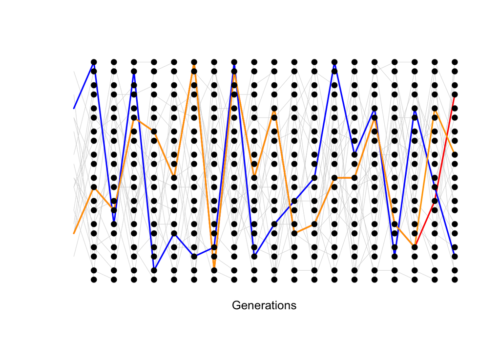

```r
track_lineages(N.vec=rep(10,20), n.iter=1, num.tracked=3)
```

Repeat this simulation 10 times. For each simulation, record the time between the present and the first coalescent event, and the time between the first coalescent event and the second coalescent event (i.e. the most recent common ancestor of all 3 lineages). You can ignore simulations where lineages have not coalesced at generation 20. Which of the two times tends to be larger? Why do you think this is?

2. Check what happens to the coalescence rate, when N = 7 and when N = 20. Do lineages coalesce faster or slower with larger population size?